# Data and tidyverse

December 8, 2016

## Packages

```r
library("tidyverse")
```

The tidyverse package loads a number of R packages that has recently been developed to support a clearner, more efficient and more coherent framework for data handling and data transformation in R.

## Core tidyverse packages

| Package | Functionality |
| --- | --- |
| tibble | Better data frames |
| dplyr | Data manipulation |
| tidyr | Data tidying |
| readr | Data IO |
| purr | Functional programming |
| ggplot2 | Graphics |

## Reading data

```r
traffic <- read_csv("../../BUinternet.txt")  ## Using the readr package
```

```
Parsed with column specification:
cols(
  `machine name` = col_character(),
  timestamp = col_integer(),
  `user id` = col_integer(),
  url = col_character(),
  size = col_integer(),
  time = col_double()
)
```

This is a classical 1995 data set from Boston University on WWW data transfers.

## The tibble data structure

```r
traffic  ## A tibble is a data frame plus more
```

```
# A tibble: 1,143,806 × 6
  `machine name` timestamp `user id`
           <chr>     <int>     <int>
1           cs21 797704541    239799
2           cs21 797704542    100378
3           cs21 797704562    318055
4           cs21 797704562    841773
5           cs21 797704563    763037
6           cs21 797704566    487965
# ... with 1.144e+06 more rows, and 3 more variables: url <chr>,
#   size <int>, time <dbl>
```

## The internet address takes a lot of space

```r
traffic[, 4]  ## This is a tibble, not a vector
```

```
# A tibble: 1,143,806 × 1
                                                     url
                                                   <chr>
1                                  http://cs-www.bu.edu/
2 http://cs-www.bu.edu/lib/logo/Ray_Chou_Logo0.small.gif
3                http://cs-www.bu.edu/pointers/Home.html
4              http://cs-www.bu.edu/lib/pics/bu-logo.gif
5             http://cs-www.bu.edu/lib/pics/bu-label.gif
6   http://cs-www.bu.edu/faculty/heddaya/navigation.html
# ... with 1.144e+06 more rows
```

## Data without the internet address

```r
traffic[, -4]
```

```
# A tibble: 1,143,806 × 5
  `machine name` timestamp `user id`  size     time
           <chr>     <int>     <int> <int>    <dbl>
1           cs21 797704541    239799  2313 0.510395
2           cs21 797704542    100378 83789 0.880251
3           cs21 797704562    318055  1558 0.429576
4           cs21 797704562    841773  1806 0.568182
5           cs21 797704563    763037   718 0.323564
6           cs21 797704566    487965  9461 0.780510
# ... with 1.144e+06 more rows
```

## Selecting

For tibbles, the intention is that the dplyr function `select` is used for variable selection instead of subsetting with `[`.

```r
traffic <- select(traffic, -url)
traffic
```

```
# A tibble: 1,143,806 × 5
  `machine name` timestamp `user id`  size     time
           <chr>     <int>     <int> <int>    <dbl>
1           cs21 797704541    239799  2313 0.510395
2           cs21 797704542    100378 83789 0.880251
3           cs21 797704562    318055  1558 0.429576
4           cs21 797704562    841773  1806 0.568182
5           cs21 797704563    763037   718 0.323564
6           cs21 797704566    487965  9461 0.780510
# ... with 1.144e+06 more rows
```

## Filtering

```r
traffic <- filter(traffic, size > 0)
traffic
```

```
# A tibble: 290,275 × 5
  `machine name` timestamp `user id`  size     time
           <chr>     <int>     <int> <int>    <dbl>
1           cs21 797704541    239799  2313 0.510395
2           cs21 797704542    100378 83789 0.880251
3           cs21 797704562    318055  1558 0.429576
4           cs21 797704562    841773  1806 0.568182
5           cs21 797704563    763037   718 0.323564
6           cs21 797704566    487965  9461 0.780510
# ... with 2.903e+05 more rows
```

## Transformation with `mutate`

```r
traffic <- mutate(traffic, speed = size / time)
traffic
```

```
# A tibble: 290,275 × 6
  `machine name` timestamp `user id`  size     time     speed
           <chr>     <int>     <int> <int>    <dbl>     <dbl>
1           cs21 797704541    239799  2313 0.510395  4531.784
2           cs21 797704542    100378 83789 0.880251 95187.623
3           cs21 797704562    318055  1558 0.429576  3626.832
4           cs21 797704562    841773  1806 0.568182  3178.559
5           cs21 797704563    763037   718 0.323564  2219.035
6           cs21 797704566    487965  9461 0.780510 12121.562
# ... with 2.903e+05 more rows
```

## Summarizing

```r
summarize(traffic, mean(speed), median(speed), mean(size), median(size))
```

```
# A tibble: 1 × 4
  `mean(speed)` `median(speed)` `mean(size)` `median(size)`
          <dbl>           <dbl>        <dbl>          <int>
1      9879.475        2908.882      14953.7           2190
```

## Tabulating and sorting

```r
trafficOrd <- arrange(
  count(traffic, `machine name`),
  n ## Sorted ascending by count, use desc(n) for descending order
)
trafficOrd
```

```
# A tibble: 37 × 2
  `machine name`     n
           <chr> <int>
1           cs18  3814
2           cs20  4764
3          kanga  5076
4          pluto  5253
5         minnie  5450
6           cs17  5847
# ... with 31 more rows
```

## Summarizing by group

```r
trafficSum <- arrange(
  summarize(
    group_by(traffic, `machine name`),
    mSpeed = mean(speed), medSpeed = median(speed),
    mSize = mean(size), medSize = median(size)
  ),
  medSize
)
```

## Summarizing by group

```r
trafficSum
```

```
# A tibble: 37 × 5
  `machine name`    mSpeed medSpeed    mSize medSize
           <chr>     <dbl>    <dbl>    <dbl>   <dbl>
1           bugs  9973.371 2363.094 13133.25  1806.0
2           cs17  8468.159 2470.481 23107.11  1919.0
3           cs18 11447.747 3129.652 26374.75  1990.5
4           cs19  9990.513 2612.308 17250.55  2023.0
5           cs21  8203.393 2543.163 15497.39  2067.0
6          kanga 10602.514 2751.867 10493.82  2069.0
# ... with 31 more rows
```

## Joining

```r
left_join(trafficSum, trafficOrd, key = `machine name`)
```

```
Joining, by = "machine name"
```

```
# A tibble: 37 × 6
  `machine name`    mSpeed medSpeed    mSize medSize     n
           <chr>     <dbl>    <dbl>    <dbl>   <dbl> <int>
1           bugs  9973.371 2363.094 13133.25  1806.0  9963
2           cs17  8468.159 2470.481 23107.11  1919.0  5847
3           cs18 11447.747 3129.652 26374.75  1990.5  3814
4           cs19  9990.513 2612.308 17250.55  2023.0  6773
5           cs21  8203.393 2543.163 15497.39  2067.0  8321
6          kanga 10602.514 2751.867 10493.82  2069.0  5076
# ... with 31 more rows
```

Here, `right_join`, `inner_join` or `full_join` would give the same.

## A scatter plot

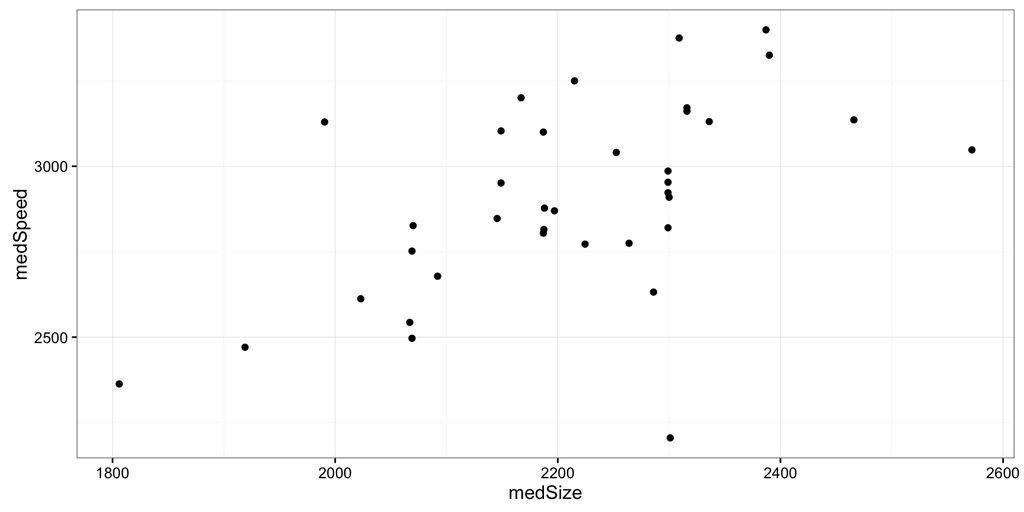

```r
p <- ggplot(trafficSum, aes(x = medSize, y = medSpeed)) +
  geom_point()  ## This geom constructs scatter plots
p  ## Evaluate p to get the figure drawn
```

## Adding aesthetics

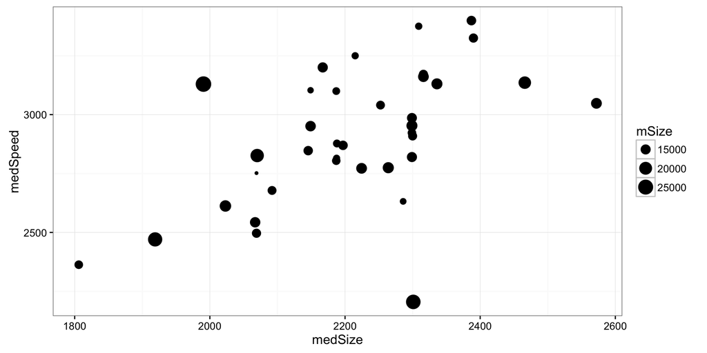

```r
p <- p + aes(size = mSize)
p
```

## Adding a regression line

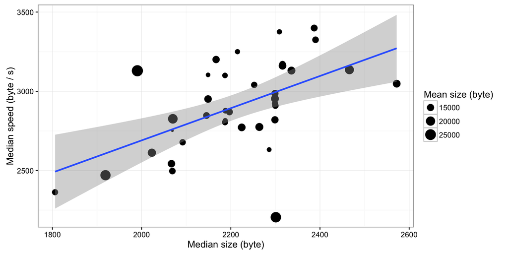

```r
p + geom_smooth(method = "lm",  ## Default is a scatter plot smoother
                show.legend = FALSE) + ## Don't mess up the legend
  xlab("Median size (byte)") + ylab("Median speed (byte / s)") +
  scale_size("Mean size (byte)")
```

## The ggplot2 world

The ggplot2 package provides via the `ggplot` function (and `qplot`) a system for declarative specification of graphics.

- Use `aes` to specify how variables are mapped to *graphical aesthetics* (x- and y-position, size, shape, color, fill)
- Use `geom_??` to specify the *geometrical object* (point, line, smooth, density, …)
- Use `stat_??` to specify a *statistical transformation* (sum, count, …).
- Add different components of a plot via `+`.

Note that typical usage requires specification of a geometrical object, which will implicitly use a statistical transformation.

## Using the larger `traffic` data

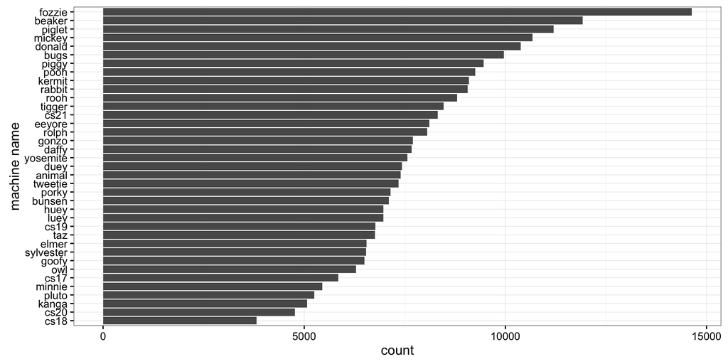

```r
ggplot(traffic) +  ## Spec. of aesthetics postponed to geom
  geom_bar(aes(x = `machine name`)) +  ## Implicit usage of `stat_count`
  coord_flip() +  ## Convenient here
  scale_x_discrete(limits = trafficOrd$`machine name`)
```

## Boxplots for each machine

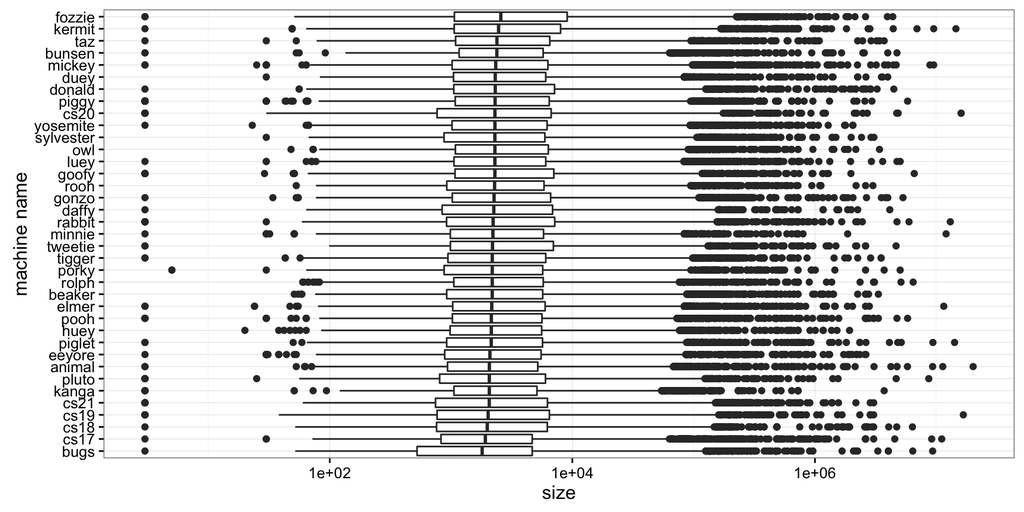

```r
ggplot(traffic) +
  geom_boxplot(aes(x = `machine name`, y = size)) +
  coord_flip() +
  scale_y_log10() + ## The distribution of size is heavy-tailed
  scale_x_discrete(limits = trafficSum$`machine name`)
```

## A scatter plot using hexagonal binning

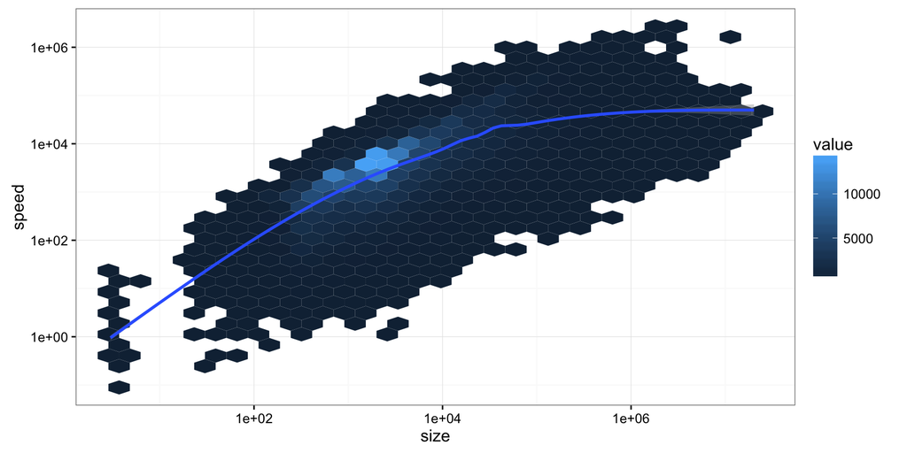

```r
ggplot(traffic, aes(x = size, y = speed)) +
  geom_hex() +
  scale_x_log10() +
  scale_y_log10() +
  geom_smooth()
```

## Alternatives

The package dplyr provides a framework for data transformation – first of all based on the tibble data structure.

- The base R functions `with`, `within`, `transform`, `aggregate`, `subset`, `rbind`, `cbind` and `merge` perform similar data transformations on data frames.
- The dplyr package can work with SQL database backends. See the Databases vignette.
- The data.table package and its `data.table` data structure is know to be fast and able to handle large tables. The dtplyr package provides a (slower) dplyr frontend to `data.table`.
- Classical R graphics via e.g. `plot`, but turn to the `lattice` package for functionality comparable to `ggplot`.